# CSC 532 - Final Project

Jackie Bastuba

This project is intended to take a dataset of various mushroom attributes to predict whether a mushroom is edible or poisonous.

[Link to the UCI data set, Mushroom Binary Classification (Edible: yes/no)](https://archive.ics.uci.edu/dataset/848/secondary+mushroom+dataset)

I will perform the following binary classification machine learning models to learn from the data set:

- Regularized Logistic Regression
  - Lasso
  - Ridge
- Tree Ensemble
  - Random Forest
  - Gradient Boosted Tree
- SVM Models
  - Linear Kernel
  - Radial Kernel
- Artificial Neural Network

# Import and Explore the dataset

```r
mushrooms <- read.csv("secondary_data.csv", header=TRUE, sep= ";", na.strings = c("", "?"), stringsAsFactors = TRUE)
```

```r
str(mushrooms)
```

```
## 'data.frame':    61069 obs. of  21 variables:
##  $ class               : Factor w/ 2 levels "e","p": 2 2 2 2 2 2 2 2 2 2 ...
##  $ cap.diameter        : num  15.3 16.6 14.1 14.2 14.6 ...
##  $ cap.shape           : Factor w/ 7 levels "b","c","f","o",..: 7 7 7 3 7 7 3 7 3 3 ...
##  $ cap.surface         : Factor w/ 11 levels "d","e","g","h",..: 3 3 3 4 4 3 4 4 3 3 ...
##  $ cap.color           : Factor w/ 12 levels "b","e","g","k",..: 7 7 7 2 7 7 7 2 7 2 ...
##  $ does.bruise.or.bleed: Factor w/ 2 levels "f","t": 1 1 1 1 1 1 1 1 1 1 ...
##  $ gill.attachment     : Factor w/ 7 levels "a","d","e","f",..: 3 3 3 3 3 3 3 3 3 3 ...
##  $ gill.spacing        : Factor w/ 3 levels "c","d","f": NA NA NA NA NA NA NA NA NA NA ...
##  $ gill.color          : Factor w/ 12 levels "b","e","f","g",..: 11 11 11 11 11 11 11 11 11 11 ...
##  $ stem.height         : num  16.9 18 17.8 15.8 16.5 ...
##  $ stem.width          : num  17.1 18.2 17.7 16 17.2 ...
##  $ stem.root           : Factor w/ 5 levels "b","c","f","r",..: 5 5 5 5 5 5 5 5 5 5 ...
##  $ stem.surface        : Factor w/ 8 levels "f","g","h","i",..: 8 8 8 8 8 8 8 8 8 8 ...
##  $ stem.color          : Factor w/ 13 levels "b","e","f","g",..: 12 12 12 12 12 12 12 12 12 12 ...
##  $ veil.type           : Factor w/ 1 level "u": 1 1 1 1 1 1 1 1 1 1 ...
##  $ veil.color          : Factor w/ 6 levels "e","k","n","u",..: 5 5 5 5 5 5 5 5 5 5 ...
##  $ has.ring            : Factor w/ 2 levels "f","t": 2 2 2 2 2 2 2 2 2 2 ...
##  $ ring.type           : Factor w/ 8 levels "e","f","g","l",..: 3 3 3 6 6 6 3 6 6 6 ...
##  $ spore.print.color   : Factor w/ 7 levels "g","k","n","p",..: NA NA NA NA NA NA NA NA NA NA ...
##  $ habitat             : Factor w/ 8 levels "d","g","h","l",..: 1 1 1 1 1 1 1 1 1 1 ...
##  $ season              : Factor w/ 4 levels "a","s","u","w": 4 3 4 4 4 3 4 3 1 4 ...
```

```r
summary(mushrooms)
```

```
##  class      cap.diameter    cap.shape  cap.surface      cap.color
##  e:27181   Min.   : 0.380   b: 5694   t      : 8196   n      :24218
##  p:33888   1st Qu.: 3.480   c: 1815   s      : 7608   y      : 8543
##            Median : 5.860   f:13404   y      : 6341   w      : 7666
##            Mean   : 6.734   o: 3460   h      : 4974   g      : 4420
##            3rd Qu.: 8.540   p: 2598   g      : 4724   e      : 4035
##            Max.   :62.340   s: 7164   (Other):15106   o      : 3656
##                             x:26934   NA's   :14120   (Other): 8531
##  does.bruise.or.bleed gill.attachment gill.spacing   gill.color
##  f:50479              a      :12698   c   :24710   w      :18521
##  t:10590              d      :10247   d   : 7766   n      : 9645
##                       x      : 7413   f   : 3530   y      : 9546
##                       p      : 6001   NA's:25063   p      : 5983
##                       e      : 5648                g      : 4118
##                       (Other): 9178                f      : 3530
##                       NA's   : 9884                (Other): 9726
##   stem.height       stem.width     stem.root     stem.surface     stem.color
##  Min.   : 0.000   Min.   :  0.00   b   : 3177   s      : 6025   w      :22926
##  1st Qu.: 4.640   1st Qu.:  5.21   c   :  706   y      : 4940   n      :18063
##  Median : 5.950   Median : 10.19   f   : 1059   i      : 4396   y      : 7865
##  Mean   : 6.582   Mean   : 12.15   r   : 1412   t      : 2644   g      : 2626
##  3rd Qu.: 7.740   3rd Qu.: 16.57   s   : 3177   g      : 1765   o      : 2187
##  Max.   :33.920   Max.   :103.91   NA's:51538   (Other): 3175   e      : 2050
##                                                 NA's   :38124   (Other): 5352
##  veil.type    veil.color   has.ring    ring.type     spore.print.color
##  u   : 3177   e   :  181   f:45890   f      :48361   k      : 2118
##  NA's:57892   k   :  353   t:15179   e      : 2435   p      : 1259
##               n   :  525             z      : 2118   w      : 1212
##               u   :  353             l      : 1427   n      : 1059
##               w   : 5474             r      : 1399   g      :  353
##               y   :  527             (Other): 2858   (Other):  353
##               NA's:53656             NA's   : 2471   NA's   :54715
##     habitat      season
##  d      :44209   a:30177
##  g      : 7943   s: 2727
##  l      : 3168   u:22898
##  m      : 2920   w: 5267
##  h      : 2001
##  p      :  360
##  (Other):  468
```

## Variable exploration

Let’s look around at any possible relationships between the individual features and the target variable.

```r
attach(mushrooms)
```

#### cap-diameter - numeric, continuous

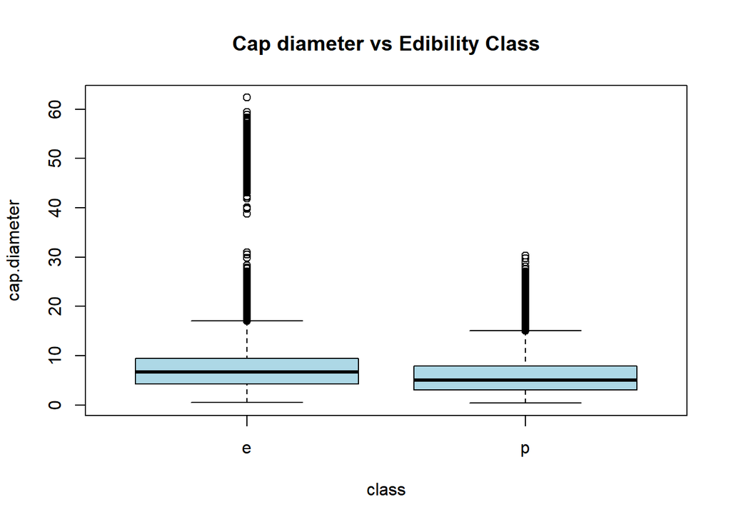

```r
boxplot(`cap.diameter` ~ class, col="lightblue", main="Cap diameter vs Edibility Class")
```

```r
t.test(`cap.diameter` ~ class)
```

```
##
##  Welch Two Sample t-test
##
## data:  cap.diameter by class
## t = 43.359, df = 43335, p-value < 2.2e-16
## alternative hypothesis: true difference in means between group e and group p is not equal to 0
## 95 percent confidence interval:
##  1.832188 2.005677
## sample estimates:
## mean in group e mean in group p
##        7.798696        5.879763
```

#### cap-shape - Categorical

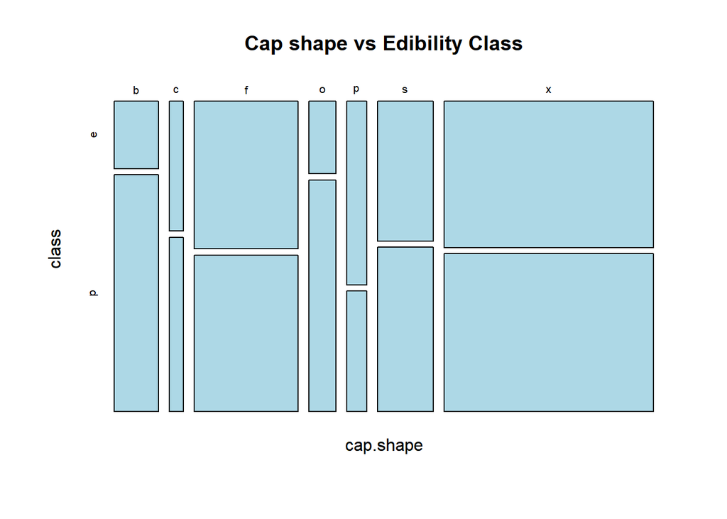

```r
mosaicplot(`cap.shape` ~ class, col="lightblue", main="Cap shape vs Edibility Class")
```

```r
chisq.test(`cap.shape`, class)
```

```
##
##  Pearson's Chi-squared test
##
## data:  cap.shape and class
## X-squared = 2257.2, df = 6, p-value < 2.2e-16
```

#### cap-surface - Categorical (missing values)

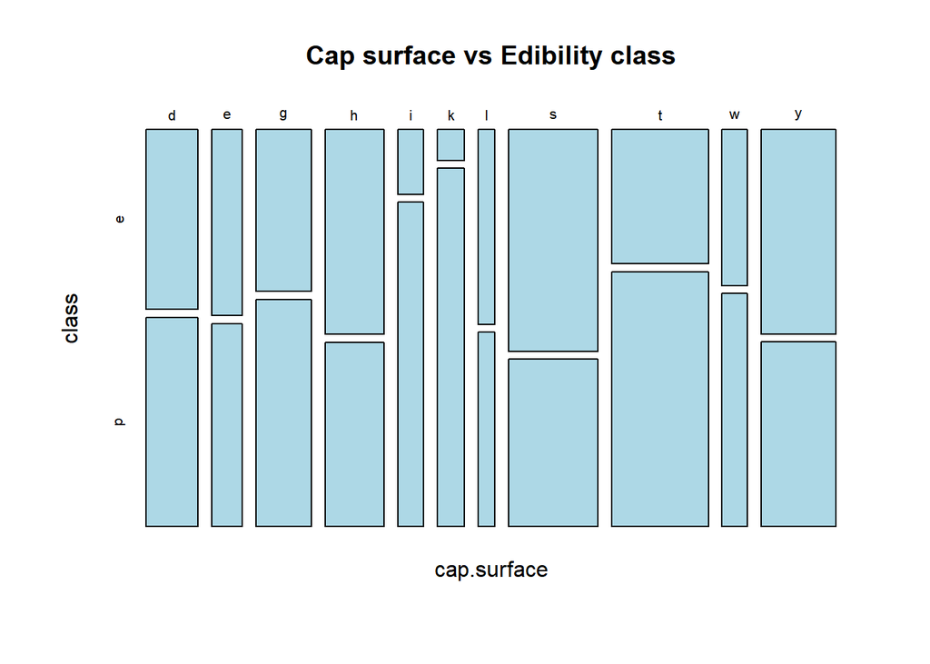

```r
mosaicplot(`cap.surface` ~ class, col="lightblue", main="Cap surface vs Edibility class")
```

```r
chisq.test(`cap.surface`, class)
```

```
##
##  Pearson's Chi-squared test
##
## data:  cap.surface and class
## X-squared = 3135.2, df = 10, p-value < 2.2e-16
```

#### cap-color - Categorical

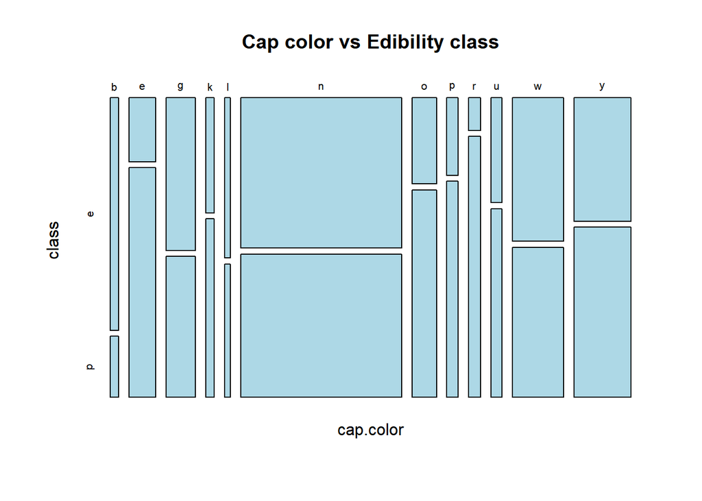

```r
mosaicplot(`cap.color` ~ class, col="lightblue", main ="Cap color vs Edibility class")
```

```r
chisq.test(`cap.color`, class)
```

```
##
##  Pearson's Chi-squared test
##
## data:  cap.color and class
## X-squared = 3541.1, df = 11, p-value < 2.2e-16
```

#### does-bruise-or-bleed - Categorical

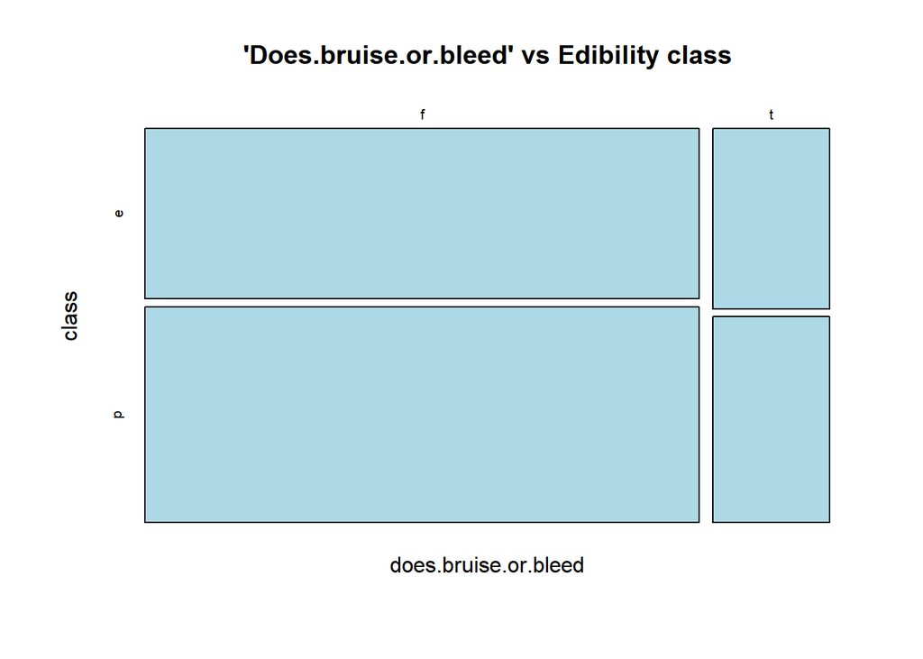

```r
mosaicplot(`does.bruise.or.bleed` ~ class, col="lightblue", main="'Does.bruise.or.bleed' vs Edibility class")
```

```r
chisq.test(`does.bruise.or.bleed`, class)
```

```
##
##  Pearson's Chi-squared test with Yates' continuity correction
##
## data:  does.bruise.or.bleed and class
## X-squared = 24.051, df = 1, p-value = 9.381e-07
```

#### gill-attachment - Categorical (missing values)

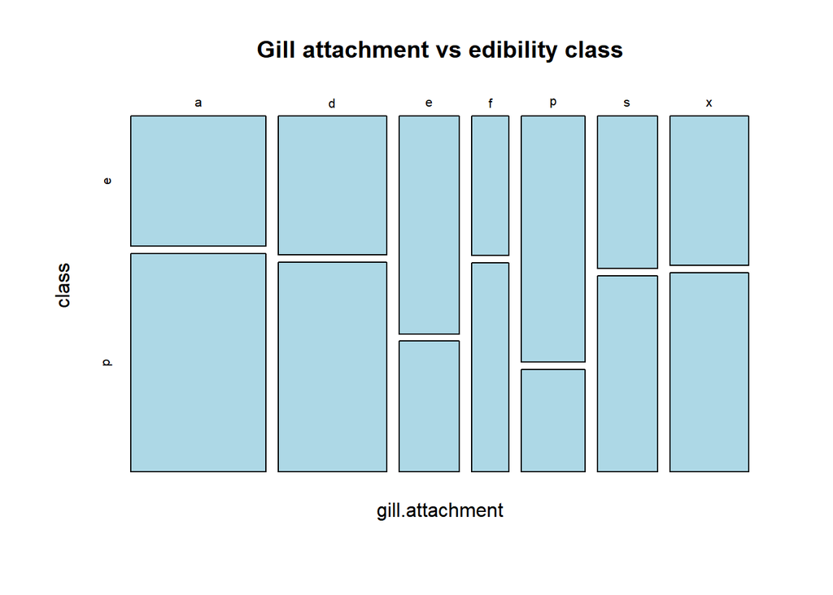

```r
mosaicplot(`gill.attachment` ~ class, col="lightblue", main="Gill attachment vs edibility class")
```

```r
chisq.test(`gill.attachment`, class)
```

```
##
##  Pearson's Chi-squared test
##
## data:  gill.attachment and class
## X-squared = 2707.7, df = 6, p-value < 2.2e-16
```

#### gill-spacing - Categorical (missing values)

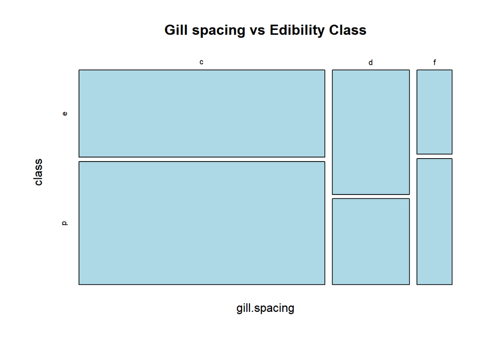

```r
mosaicplot(`gill.spacing` ~ class, col="lightblue", main="Gill spacing vs Edibility Class")
```

```r
chisq.test(`gill.spacing`, class)
```

```
##
##  Pearson's Chi-squared test
##
## data:  gill.spacing and class
## X-squared = 785.57, df = 2, p-value < 2.2e-16
```

#### gill-color - Categorical

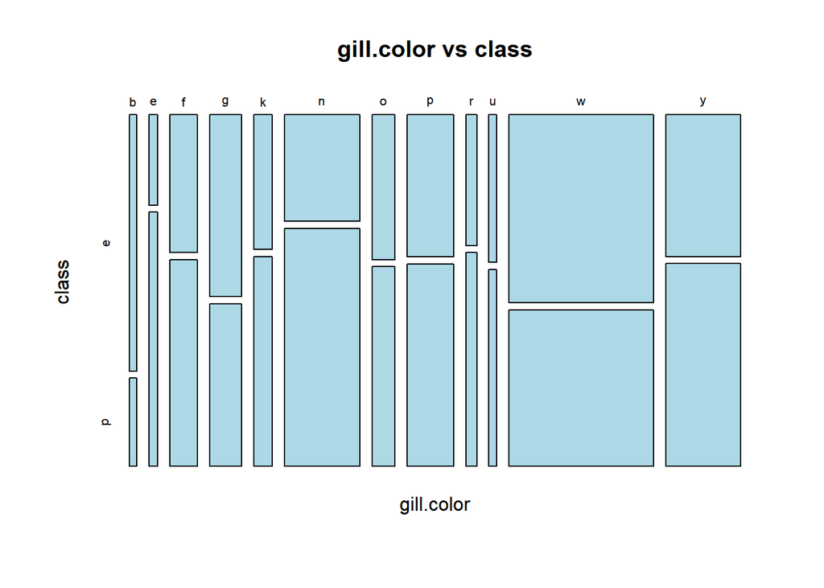

```r
mosaicplot(`gill.color` ~ class, col="lightblue", main="gill.color vs class")
```

```r
chisq.test(`gill.color`, class)
```

```
##
##  Pearson's Chi-squared test
##
## data:  gill.color and class
## X-squared = 2245, df = 11, p-value < 2.2e-16
```

#### stem-height - numeric, continuous

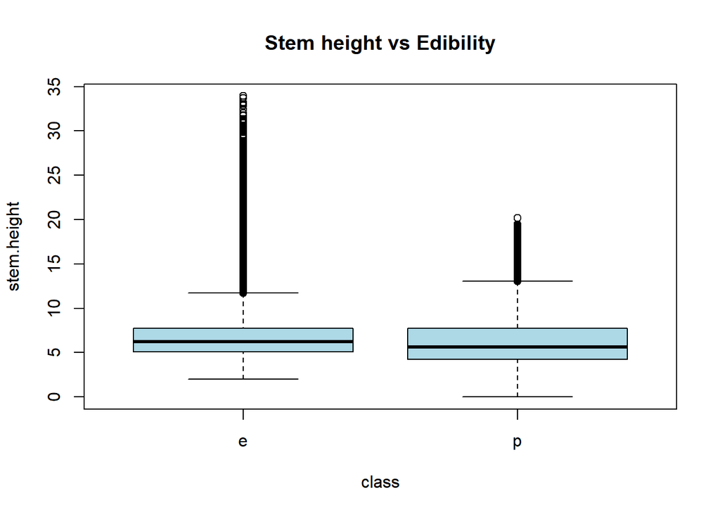

```r
boxplot(`stem.height` ~ class, col="lightblue", main="Stem height vs Edibility")
```

```r
t.test(`stem.height` ~ class)
```

```
##
##  Welch Two Sample t-test
##
## data:  stem.height by class
## t = 29.84, df = 54422, p-value < 2.2e-16
## alternative hypothesis: true difference in means between group e and group p is not equal to 0
## 95 percent confidence interval:
##  0.7703636 0.8786807
## sample estimates:
## mean in group e mean in group p
##        7.039077        6.214554
```

#### stem-width - numeric, continuous

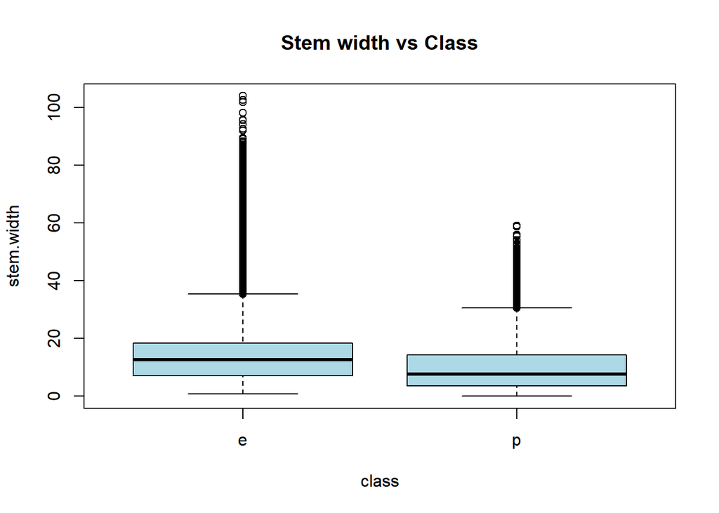

```r
boxplot(`stem.width` ~ class, col="lightblue", main="Stem width vs Class")
```

```r
t.test(`stem.width` ~ class)
```

```
##
##  Welch Two Sample t-test
##
## data:  stem.width by class
## t = 48.52, df = 51077, p-value < 2.2e-16
## alternative hypothesis: true difference in means between group e and group p is not equal to 0
## 95 percent confidence interval:
##  3.824618 4.146623
## sample estimates:
## mean in group e mean in group p
##        14.36108        10.37546
```

#### stem-root - Categorical (missing values)

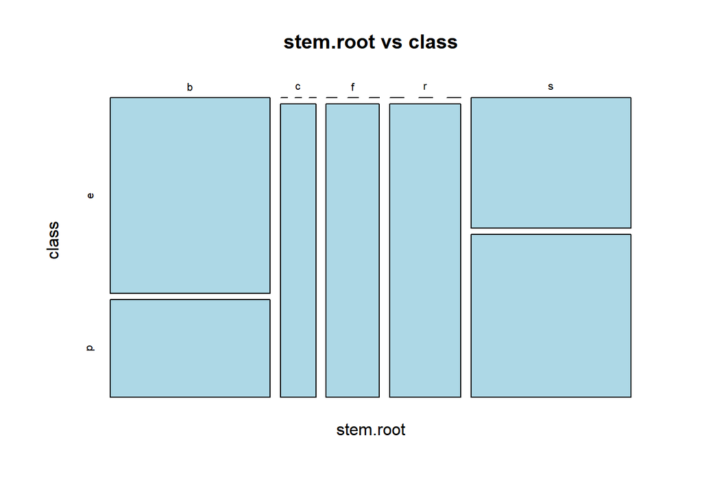

```r
mosaicplot(`stem.root` ~ class, col="lightblue", main="stem.root vs class")
```

```r
chisq.test(`stem.root`, class)
```

```
##
##  Pearson's Chi-squared test
##
## data:  stem.root and class
## X-squared = 3139.6, df = 4, p-value < 2.2e-16
```

#### stem-surface - Categorical (missing values)

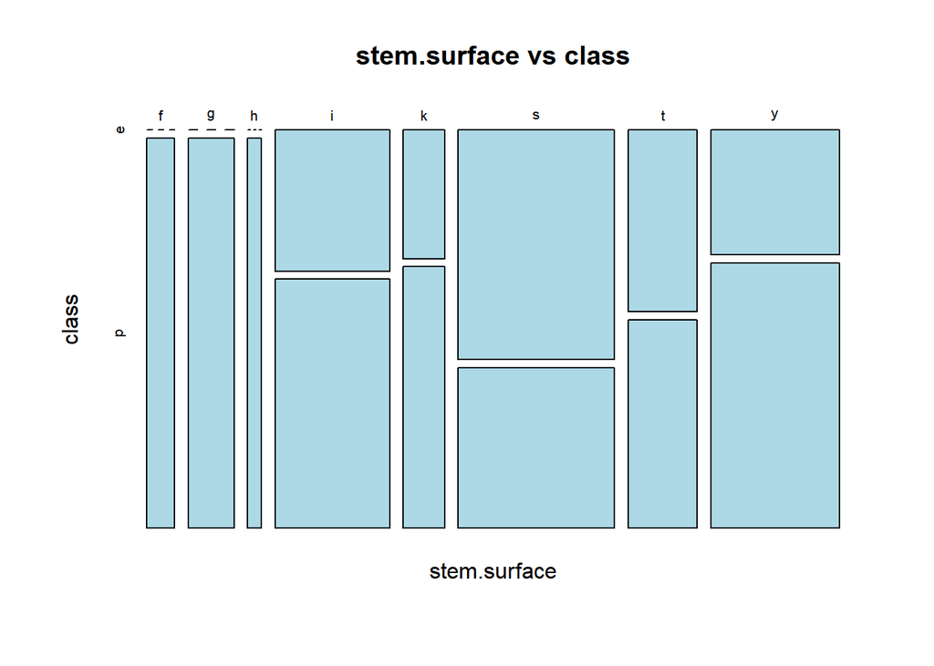

```r
mosaicplot(`stem.surface` ~ class, col="lightblue", main="stem.surface vs class")
```

```r
chisq.test(`stem.surface`, class)
```

```
##
##  Pearson's Chi-squared test
##
## data:  stem.surface and class
## X-squared = 3382.1, df = 7, p-value < 2.2e-16
```

#### stem-color - Categorical

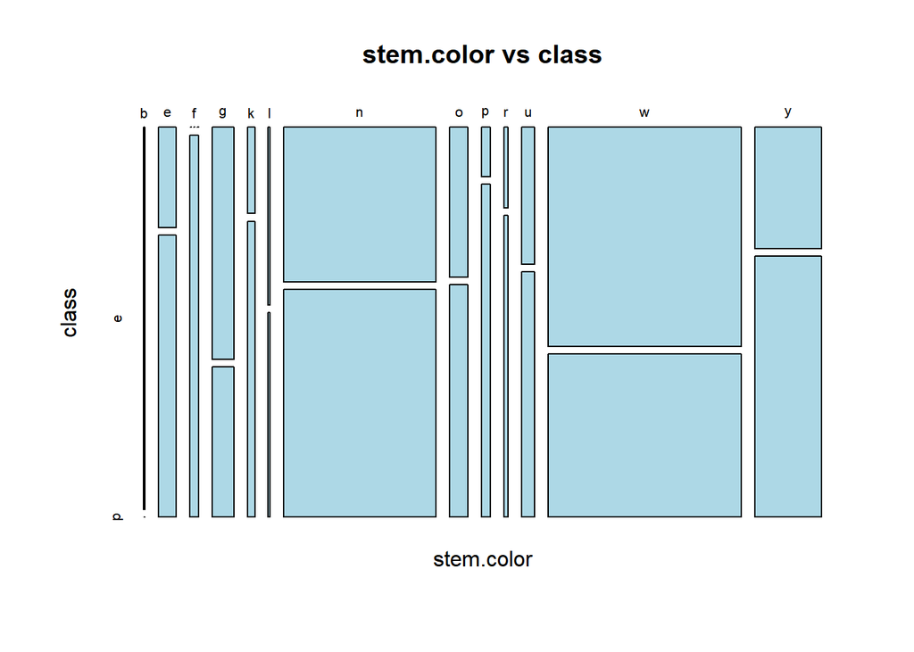

```r
mosaicplot(`stem.color` ~ class, col="lightblue", main="stem.color vs class")
```

```r
chisq.test(`stem.color`, class)
```

```
##
##  Pearson's Chi-squared test
##
## data:  stem.color and class
## X-squared = 4557.9, df = 12, p-value < 2.2e-16
```

#### veil-type - Categorical (missing values)

```r
sum(is.na(`veil.type`))
```

```
## [1] 57892
```

```r
unique(`veil.type`)
```

```
## [1] u    <NA>
## Levels: u
```

After further review of this feature, the only input values are “u” (universal) or NA. Therefore I will remove this variable since it does not provide enough information or variety to assist with prediction.

```r
mushrooms$`veil.type` = NULL
```

#### veil-color - Categorical (missing values)

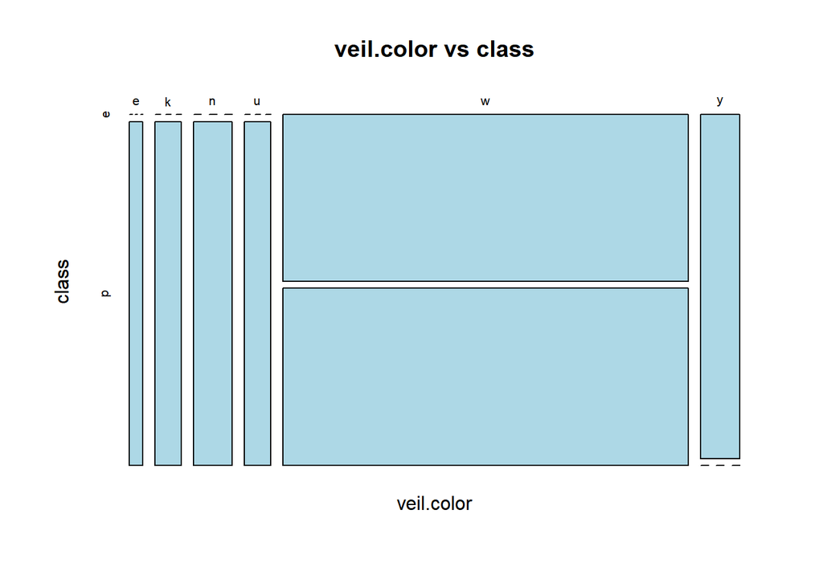

```r
mosaicplot(`veil.color` ~ class, col="lightblue", main="veil.color vs class")
```

```r
chisq.test(`veil.color`, class)
```

```
##
##  Pearson's Chi-squared test
##
## data:  veil.color and class
## X-squared = 1830.6, df = 5, p-value < 2.2e-16
```

#### has-ring - Categorical

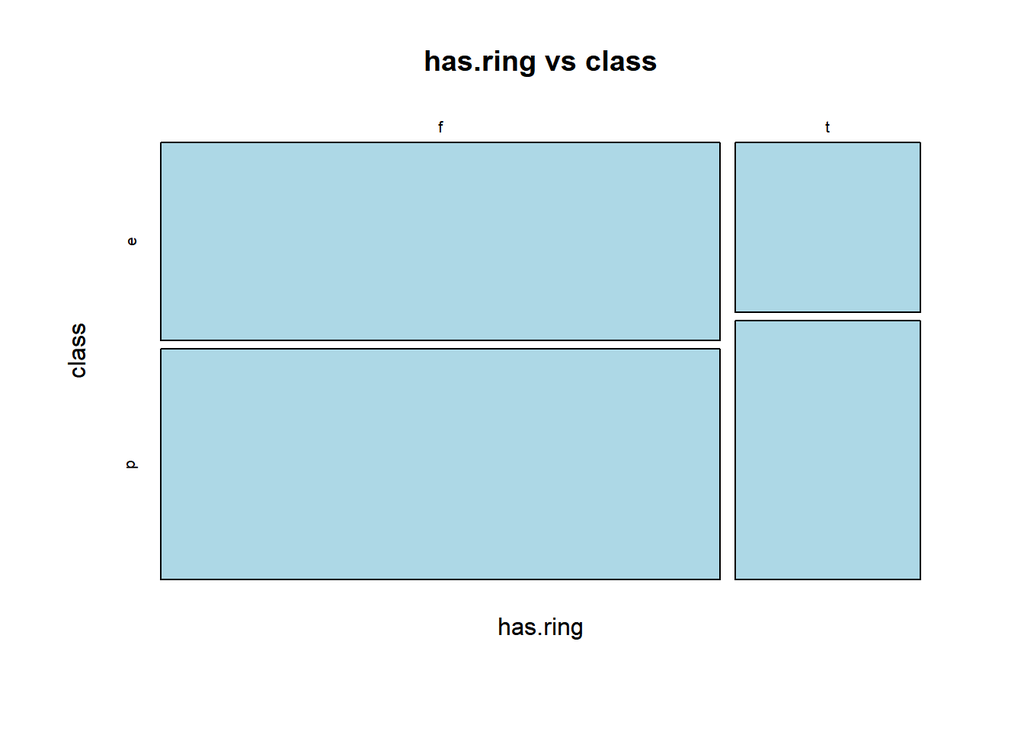

```r
mosaicplot(`has.ring` ~ class, col="lightblue", main="has.ring vs class")
```

```r
chisq.test(`has.ring`, class)
```

```
##
##  Pearson's Chi-squared test with Yates' continuity correction
##
## data:  has.ring and class
## X-squared = 202.06, df = 1, p-value < 2.2e-16
```

#### ring-type - Categorical

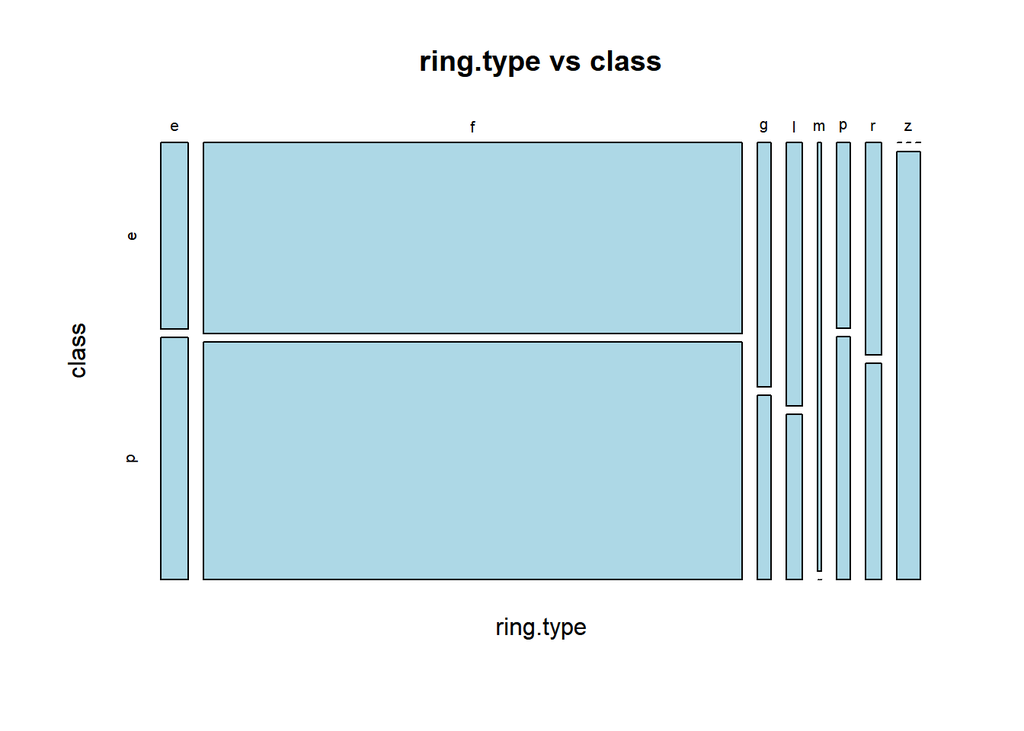

```r
mosaicplot(`ring.type` ~ class, col="lightblue", main="ring.type vs class")
```

```r
chisq.test(`ring.type`, class)
```

```
##
##  Pearson's Chi-squared test
##
## data:  ring.type and class
## X-squared = 2397.7, df = 7, p-value < 2.2e-16
```

#### spore-print-color - Categorical

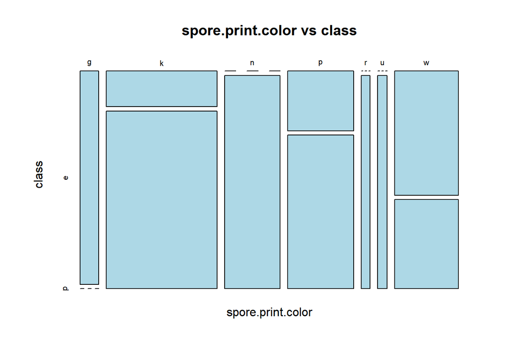

```r
mosaicplot(`spore.print.color` ~ class, col="lightblue", main="spore.print.color vs class")
```

```r
chisq.test(`spore.print.color`, class)
```

```
##
##  Pearson's Chi-squared test
##
## data:  spore.print.color and class
## X-squared = 2152.3, df = 6, p-value < 2.2e-16
```

#### habitat - Categorical

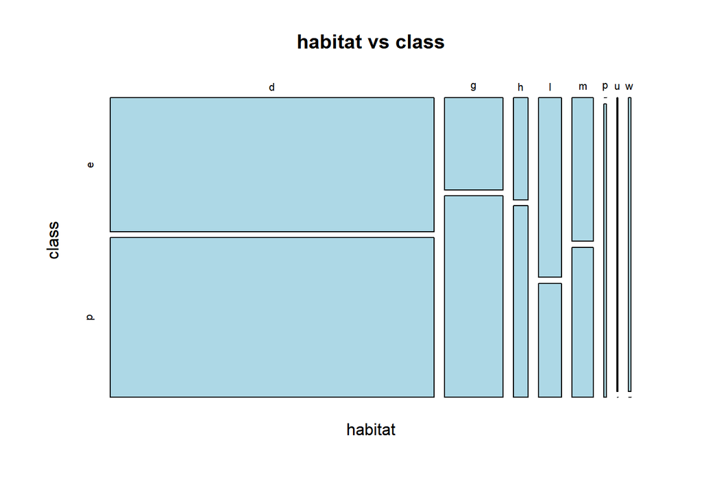

```r
mosaicplot(`habitat` ~ class, col="lightblue", main="habitat vs class")
```

```r
chisq.test(`habitat`, class)
```

```
##
##  Pearson's Chi-squared test
##
## data:  habitat and class
## X-squared = 1907.3, df = 7, p-value < 2.2e-16
```

#### season - Categorical

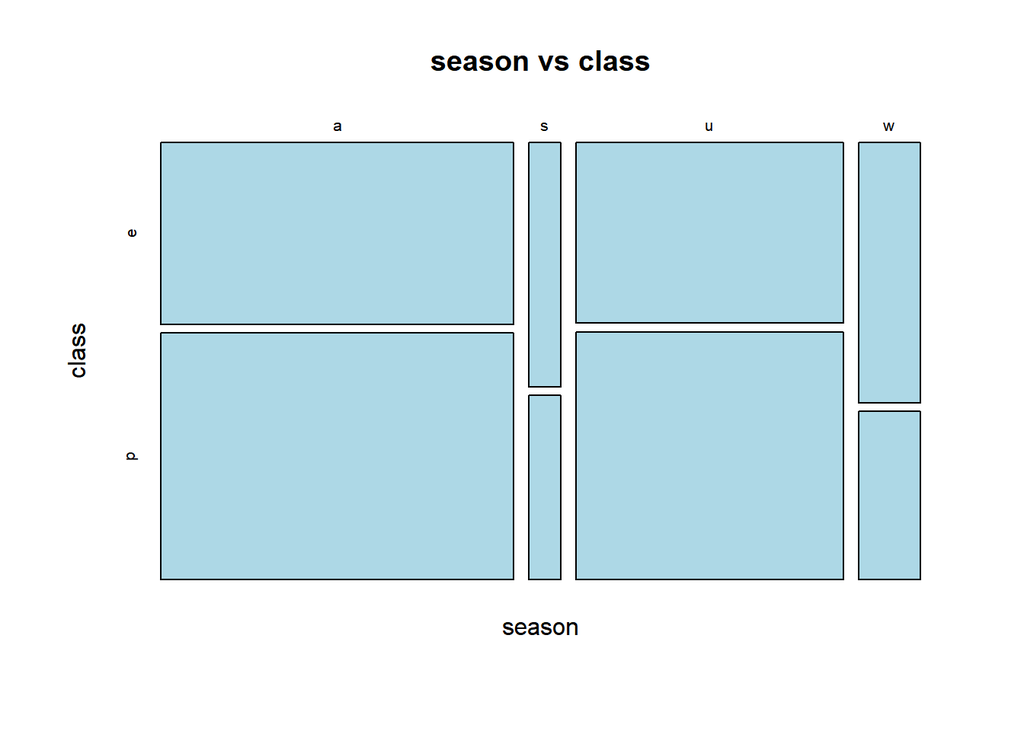

```r
mosaicplot(`season` ~ class, col="lightblue", main="season vs class")
```

```r
chisq.test(`season`, class)
```

```
##
##  Pearson's Chi-squared test
##
## data:  season and class
## X-squared = 837.03, df = 3, p-value < 2.2e-16
```

#### class - target variable - Categorical

```r
library(ggplot2)
```

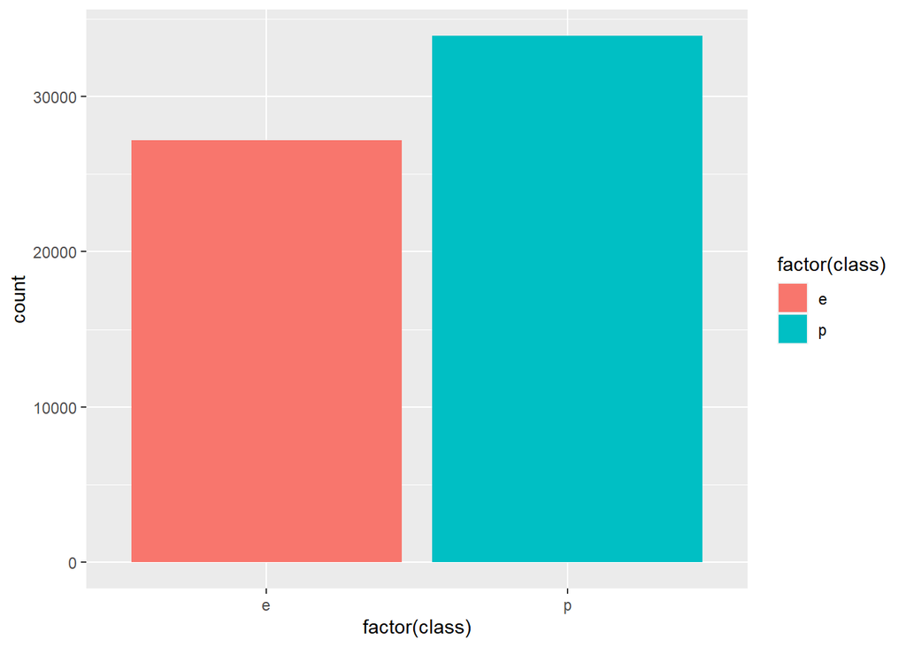

```r
#The following code was adapted from: https://www.guru99.com/r-bar-chart-histogram.html
#found via web search of "histogram of categorical variable R"
ggplot(mushrooms, aes(factor(class),
                   fill = factor(class))) +
                    geom_bar()
```

While the data is not perfectly balanced for the target variable, class, there are a good deal of “edible” mushrooms available for the machine learning models to learn from.

All of the features are considered significant via their p-values. The various types of plots all clearly indicate that there is a difference in the proportion or means between the predictor variables and the target variable.

## Feature Engineering

### Imputing Missing Values

There are several features with missing values, the *veil-type* feature was removed since it was primarily composed of NAs. The remaining features with missing values are as follows,

```r
for (i in 1:dim(mushrooms)[2]) {
  if (any(is.na(mushrooms[i])) == TRUE) {print(colnames(mushrooms[i]))}
}
```

```
## [1] "cap.surface"
## [1] "gill.attachment"
## [1] "gill.spacing"
## [1] "stem.root"
## [1] "stem.surface"
## [1] "veil.color"
## [1] "ring.type"
## [1] "spore.print.color"
```

Given that these are all categorical features and they are considered significant for the information that they provide when it *is* present, I will need to impute the missing values. I will substitute the missing values for 0. Since R is based on a 1-index, the current factors will not already have a 0 level. Adding a new character value would adjust the feature to a character/mixed type, which will pose significant issues later when trying to encode the categorical data.

I will not divide the data into training/test yet because there is no mathematical imputation with these categorical features that would lead to data leakage.

```r
#replace the missing values
mushrooms$`cap.surface` <- ifelse(is.na(mushrooms$`cap.surface`), 0, mushrooms$`cap.surface`)
mushrooms$`gill.attachment` <- ifelse(is.na(mushrooms$`gill.attachment`), 0, mushrooms$`gill.attachment`)
mushrooms$`gill.spacing` <- ifelse(is.na(mushrooms$`gill.spacing`), 0, mushrooms$`gill.spacing`)
mushrooms$`stem.root` <- ifelse(is.na(mushrooms$`stem.root`), 0, mushrooms$`stem.root`)
mushrooms$`stem.surface` <- ifelse(is.na(mushrooms$`stem.surface`), 0, mushrooms$`stem.surface`)
mushrooms$`veil.color` <- ifelse(is.na(mushrooms$`veil.color`), 0, mushrooms$`veil.color`)
mushrooms$`ring.type` <- ifelse(is.na(mushrooms$`ring.type`), 0, mushrooms$`ring.type`)
mushrooms$`spore.print.color` <- ifelse(is.na(mushrooms$`spore.print.color`), 0, mushrooms$`spore.print.color`)
```

Now, I can shuffle and divide the data into train, validation, and test sets

```r
library(caret)
```

```r
set.seed(1)
#shuffle
mushrooms <- mushrooms[sample(nrow(mushrooms), replace = FALSE), ]

#divide to train and test
trainIndex <- createDataPartition(mushrooms$class, p = 0.75, list = FALSE)
mush_train <- mushrooms[trainIndex, ]
mush_test <- mushrooms[-trainIndex, ]

#further divide train set to train and validation
trainIndex <- createDataPartition(mush_train$class, p = 0.75, list = FALSE)
mush_train <- mush_train[trainIndex, ]
mush_val <- mush_train[-trainIndex, ]
```

# Creating a Simple Benchmark

```r
library(ROCR)
```

```r
bench_table <- table(mush_train$class)
bench_table
```

```
##
##     e     p
## 15290 19062
```

The “edible” class makes up 44.50% of the training data. Therefore, my benchmark will be to predict “edible” 44.5% of the time.

```r
#specifically takes an integer as input to determine how long the
#returned vector should be
benchmark_predict_fcn = function (x) {
  y = vector(length = x) #vector to store the predictions
   for (i in 1:x) {
      j = (sample(0:1000, size=1))
      if (j < 446) {y[i] = 1} #1 = e (edible)
      else {y[i] = 2} #2 = p (poisonous)
   }
   return (y)
}
```

```r
#get the predictions
set.seed(1)
benchmark_p <- benchmark_predict_fcn(length(mush_val$class))
benchmark_p <- factor(benchmark_p, levels = c(1,2), labels=c("e", "p"))
```

```r
table(mush_val$class, benchmark_p)
```

```
##    benchmark_p
##        e    p
##   e 1739 2132
##   p 2129 2676
```

With respect to correctly predicting “edible,” the metrics of accuracy are as follows:

```r
#Calculate metrics of accuracy
TP = 1739
FP = 2129
FN = 2132
TN = 2676
obs_total <- 1739+2129+2132+2676
bench_specificity = TN / (TN + FP)
bench_precision = TP / (TP + FP)
bench_sensitivity = TP / (TP + FN)
bench_acc <- (1739+2676) / obs_total
f <-(2 * bench_precision* bench_sensitivity) / (bench_precision + bench_sensitivity)
cat("Precision: ", bench_specificity, "\n")
```

```
## Precision:  0.5569199
```

```r
cat("Recall: ", bench_sensitivity, "\n")
```

```
## Recall:  0.4492379
```

```r
cat("F-measure: ", f, "\n")
```

```
## F-measure:  0.4494121
```

```r
#kappa calculations
pred_edible <- (1739+2129) / obs_total
act_edible <- (1739+2132) / obs_total
pred_poison <- (2132+2676) / obs_total
act_poison <- (2129+2676) / obs_total
pr_e <- act_edible * pred_edible + act_poison * pred_poison
bench_kappa <-  (bench_acc - pr_e) / (1 - pr_e)
```

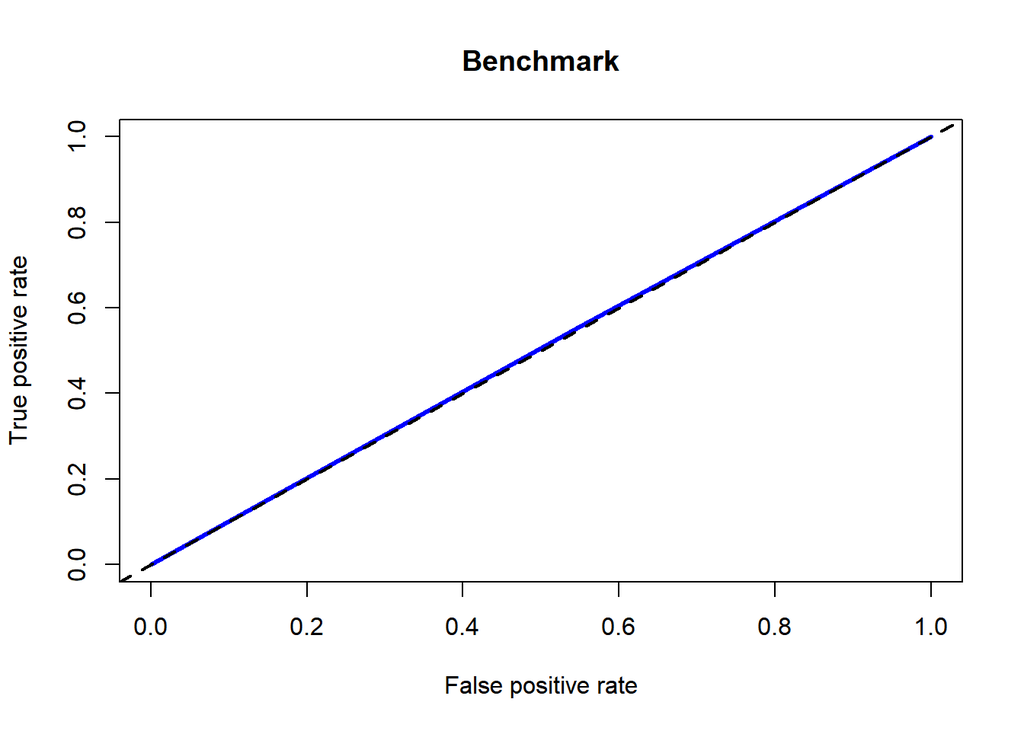

```r
#construct the ROC curve
bench_pred <- prediction(predictions = as.numeric(benchmark_p), labels = as.numeric(mush_val$class))
bench_perf <- performance(bench_pred, measure = "tpr", x.measure= "fpr")
plot(bench_perf, main = "Benchmark", col = "blue", lwd= 3)
abline(a = 0, b = 1, lwd= 2, lty= 2)
```

```r
#calculate AUC
bench.perf.auc<-performance(bench_pred, measure = "auc")
bench_auc <- unlist(bench.perf.auc@y.values)
```

# Training ML models

## Regularized Logistic Regression Models

### Lasso

```r
#Perform Lasso Logistic regression with 10-fold cross validation
set.seed(1)
lasso <- train(class ~ . , data=mush_train,
               method ="glmnet",
               metric="Accuracy",
               trControl= trainControl(method="cv", number=10, classProbs=TRUE),
               tuneGrid= expand.grid(alpha = 1, lambda = 10^seq(-3, 3, length = 100)))
```

```r
coef(lasso$finalModel, lasso$bestTune$lambda)
```

```
## 64 x 1 sparse Matrix of class "dgCMatrix"
##                                  s1
## (Intercept)            1.4546586080
## cap.diameter          -0.0964595666
## cap.shapec            -0.2117244852
## cap.shapef            -1.0402198760
## cap.shapeo             0.2290038237
## cap.shapep            -1.2526698603
## cap.shapes            -0.9667057649
## cap.shapex            -1.4710161569
## cap.surface           -0.0162960509
## cap.colore             1.5649500905
## cap.colorg             0.2523772705
## cap.colork             1.0793285678
## cap.colorl             0.4989932277
## cap.colorn            -0.0072127026
## cap.coloro             0.7070995942
## cap.colorp             0.7884149124
## cap.colorr             2.6080846056
## cap.coloru             0.7377846691
## cap.colorw             0.5177076209
## cap.colory             0.4942717690
## does.bruise.or.bleedt  0.0019010657
## gill.attachment       -0.0517828910
## gill.spacing          -0.1020221029
## gill.colore            1.0344474611
## gill.colorf           -0.2894627876
## gill.colorg           -0.3461771086
## gill.colork            0.4268564263
## gill.colorn            0.7713035159
## gill.coloro            0.3624514610
## gill.colorp            0.4989717293
## gill.colorr            .
## gill.coloru            0.1347780756
## gill.colorw            .
## gill.colory            0.8195849107
## stem.height           -0.0672131486
## stem.width             0.0006698576
## stem.root              0.4052834069
## stem.surface           0.0700173755
```

[output cut: 11 more lines]

```
## stem.colory            0.2652145815
## veil.color            -0.1064611981
## has.ringt              0.5088287567
## ring.type              0.1938335484
## spore.print.color      0.0986347068
## habitatg               0.5140822733
## habitath              -0.1046541735
## habitatl              -0.4891063284
## habitatm              -0.5606528667
## habitatp               3.1386351043
## habitatu              -2.2978664007
## habitatw              -4.7743321661
## seasons               -0.9627512199
## seasonu                .
## seasonw               -0.9527519402
```

#### Predictions on the Validation data

```r
lasso_predictions <- predict(lasso, mush_val)
confusionMatrix(as.factor(lasso_predictions), as.factor(mush_val$class), positive="e")
```

```
## Confusion Matrix and Statistics
##
##           Reference
## Prediction    e    p
##          e 2719 1004
##          p 1152 3801
##
##                Accuracy : 0.7515
##                  95% CI : (0.7423, 0.7606)
##     No Information Rate : 0.5538
##     P-Value [Acc > NIR] : < 2.2e-16
##
##                   Kappa : 0.4953
##
##  Mcnemar's Test P-Value : 0.001546
##
##             Sensitivity : 0.7024
##             Specificity : 0.7911
##          Pos Pred Value : 0.7303
##          Neg Pred Value : 0.7674
##              Prevalence : 0.4462
##          Detection Rate : 0.3134
##    Detection Prevalence : 0.4291
##       Balanced Accuracy : 0.7467
##
##        'Positive' Class : e
##
```

```r
lasso_acc <- 0.7515
```

##### Area under ROC curve

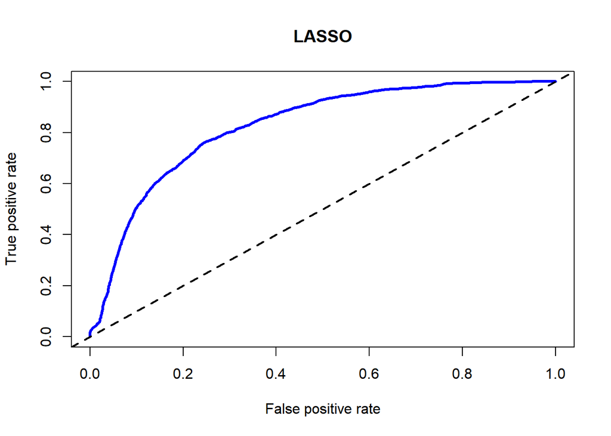

```r
lasso_predictions_prob=predict(lasso, mush_val, type="prob")
pred_lasso <- prediction(predictions = lasso_predictions_prob$e, labels = mush_val$class, label.ordering = c("p","e"))
perf_lasso <- performance(pred_lasso, measure = "tpr", x.measure= "fpr")

#plot the ROC curve
plot(perf_lasso, main = "LASSO", col = "blue", lwd= 3)
abline(a = 0, b = 1, lwd= 2, lty= 2)
```

```r
#get the AUC
lasso.perf.auc<-performance(pred_lasso, measure = "auc")
lasso_auc <- unlist(lasso.perf.auc@y.values)
```

### Ridge

```r
set.seed(1)
ridge <- train(class ~ . , data=mush_val,
               method ="glmnet",
               metric="Accuracy",
               trControl= trainControl(method="cv", number=10),
               tuneGrid= expand.grid(alpha = 0, lambda = 10^seq(-3, 3, length = 100)))
```

```r
ridge
```

```
## glmnet
##
## 8676 samples
##   19 predictor
##    2 classes: 'e', 'p'
##
## No pre-processing
## Resampling: Cross-Validated (10 fold)
## Summary of sample sizes: 7809, 7808, 7808, 7808, 7809, 7808, ...
## Resampling results across tuning parameters:
##
##   lambda        Accuracy   Kappa
##   1.000000e-03  0.7457372  0.483570363
##   1.149757e-03  0.7457372  0.483570363
##   1.321941e-03  0.7457372  0.483570363
##   1.519911e-03  0.7457372  0.483570363
##   1.747528e-03  0.7457372  0.483570363
##   2.009233e-03  0.7457372  0.483570363
##   2.310130e-03  0.7457372  0.483570363
##   2.656088e-03  0.7457372  0.483570363
##   3.053856e-03  0.7457372  0.483570363
##   3.511192e-03  0.7457372  0.483570363
##   4.037017e-03  0.7457372  0.483570363
##   4.641589e-03  0.7457372  0.483570363
##   5.336699e-03  0.7457372  0.483570363
##   6.135907e-03  0.7457372  0.483570363
##   7.054802e-03  0.7457372  0.483570363
##   8.111308e-03  0.7457372  0.483570363
##   9.326033e-03  0.7457372  0.483570363
##   1.072267e-02  0.7457372  0.483542174
##   1.232847e-02  0.7455065  0.482944449
##   1.417474e-02  0.7449297  0.481635246
##   1.629751e-02  0.7448139  0.481306422
##   1.873817e-02  0.7448139  0.481173773
##   2.154435e-02  0.7437767  0.478865551
##   2.477076e-02  0.7438921  0.478878735
##   2.848036e-02  0.7433148  0.477581217
##   3.274549e-02  0.7425073  0.475797906
##   3.764936e-02  0.7403175  0.471188180
##   4.328761e-02  0.7390496  0.468248418
```

[output cut: 61 more lines]

```
##   2.477076e+02  0.5538266  0.000000000
##   2.848036e+02  0.5538266  0.000000000
##   3.274549e+02  0.5538266  0.000000000
##   3.764936e+02  0.5538266  0.000000000
##   4.328761e+02  0.5538266  0.000000000
##   4.977024e+02  0.5538266  0.000000000
##   5.722368e+02  0.5538266  0.000000000
##   6.579332e+02  0.5538266  0.000000000
##   7.564633e+02  0.5538266  0.000000000
##   8.697490e+02  0.5538266  0.000000000
##   1.000000e+03  0.5538266  0.000000000
##
## Tuning parameter 'alpha' was held constant at a value of 0
## Accuracy was used to select the optimal model using the largest value.
## The final values used for the model were alpha = 0 and lambda = 0.01072267.
```

##### Predictions on Validation Data

```r
ridge_predictions <- predict(ridge, mush_val)
confusionMatrix(as.factor(ridge_predictions), as.factor(mush_val$class), positive="e")
```

```
## Confusion Matrix and Statistics
##
##           Reference
## Prediction    e    p
##          e 2709  995
##          p 1162 3810
##
##                Accuracy : 0.7514
##                  95% CI : (0.7421, 0.7604)
##     No Information Rate : 0.5538
##     P-Value [Acc > NIR] : < 2.2e-16
##
##                   Kappa : 0.4948
##
##  Mcnemar's Test P-Value : 0.0003513
##
##             Sensitivity : 0.6998
##             Specificity : 0.7929
##          Pos Pred Value : 0.7314
##          Neg Pred Value : 0.7663
##              Prevalence : 0.4462
##          Detection Rate : 0.3122
##    Detection Prevalence : 0.4269
##       Balanced Accuracy : 0.7464
##
##        'Positive' Class : e
##
```

```r
ridge_acc <- 0.7514
```

##### Area under ROC curve

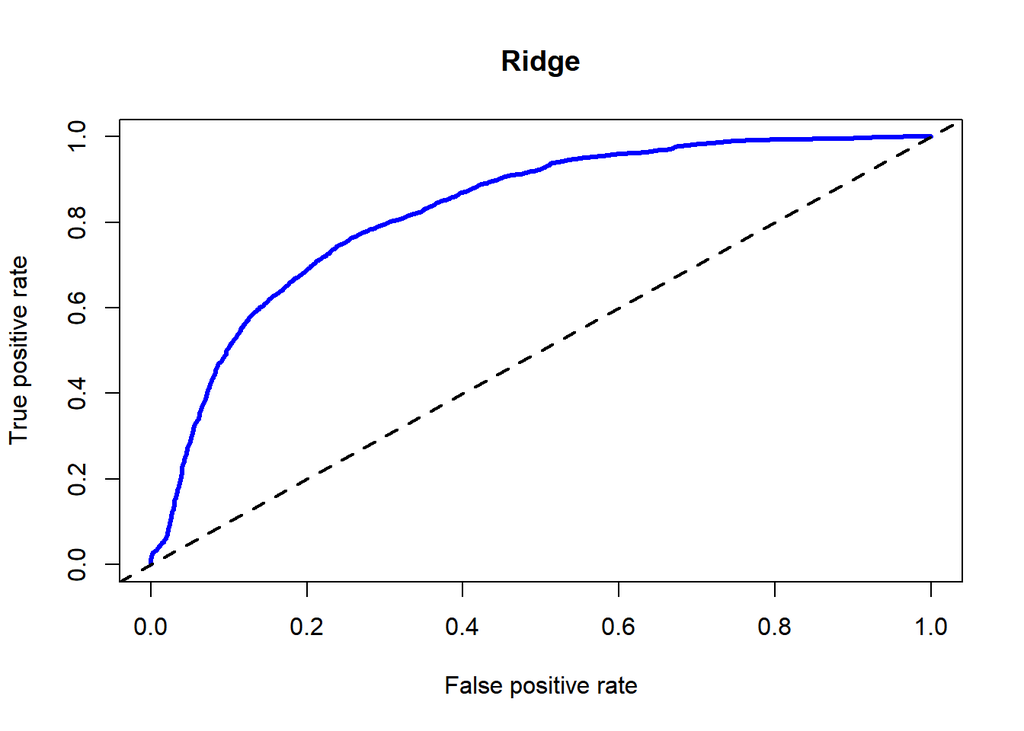

```r
ridge_predictions_prob=predict(ridge, mush_val, type="prob")
pred_ridge <- prediction(ridge_predictions_prob$e, mush_val$class, label.ordering = c("p","e"))
perf_ridge<- performance(pred_ridge, measure = "tpr", x.measure= "fpr")

#plot the ROC curve
plot(perf_ridge, main = "Ridge", col = "blue", lwd= 3)
abline(a = 0, b = 1, lwd= 2, lty= 2)
```

```r
#get the AUC
ridge.perf.auc<-performance(pred_ridge, measure = "auc")
ridge_auc <- unlist(ridge.perf.auc@y.values)
```

## Tree Ensembles

### Random Forest

```r
set.seed(1)
rf <- train(mush_train[-1], mush_train$class,
               method ="rf",
               trControl= trainControl(method="cv", number=10),
               importance=T)
rf
```

```
## Random Forest
##
## 34352 samples
##    19 predictor
##     2 classes: 'e', 'p'
##
## No pre-processing
## Resampling: Cross-Validated (10 fold)
## Summary of sample sizes: 30916, 30917, 30917, 30917, 30917, 30917, ...
## Resampling results across tuning parameters:
##
##   mtry  Accuracy   Kappa
##    2    0.9999127  0.9998232
##   10    0.9998544  0.9997053
##   19    0.9991849  0.9983498
##
## Accuracy was used to select the optimal model using the largest value.
## The final value used for the model was mtry = 2.
```

```r
varImp(rf)
```

```
## rf variable importance
##
##                      Importance
## cap.color                100.00
## gill.color                92.11
## gill.spacing              80.56
## stem.color                79.33
## cap.surface               78.45
## cap.shape                 70.90
## stem.width                59.80
## stem.height               55.06
## gill.attachment           54.16
## ring.type                 49.59
## stem.root                 46.11
## cap.diameter              44.09
## stem.surface              38.06
## habitat                   34.98
## does.bruise.or.bleed      22.73
## has.ring                  17.08
## veil.color                16.29
## season                    14.18
## spore.print.color          0.00
```

The most important variables include cap.color, gill.color, stem.color, cap.shape, cap.surface, gill.spacing, stem.width, stem.height, gill.attachment, and stem.root. None of these are imputed variable values, so that is a good sign.

##### Predictions on Validation Data

```r
rf_predictions <- predict(rf, mush_val)
confusionMatrix(as.factor(rf_predictions), as.factor(mush_val$class), positive="e")
```

```
## Confusion Matrix and Statistics
##
##           Reference
## Prediction    e    p
##          e 3871    0
##          p    0 4805
##
##                Accuracy : 1
##                  95% CI : (0.9996, 1)
##     No Information Rate : 0.5538
##     P-Value [Acc > NIR] : < 2.2e-16
##
##                   Kappa : 1
##
##  Mcnemar's Test P-Value : NA
##
##             Sensitivity : 1.0000
##             Specificity : 1.0000
##          Pos Pred Value : 1.0000
##          Neg Pred Value : 1.0000
##              Prevalence : 0.4462
##          Detection Rate : 0.4462
##    Detection Prevalence : 0.4462
##       Balanced Accuracy : 1.0000
##
##        'Positive' Class : e
##
```

```r
rf_acc <- 1.0
```

##### Area under ROC curve

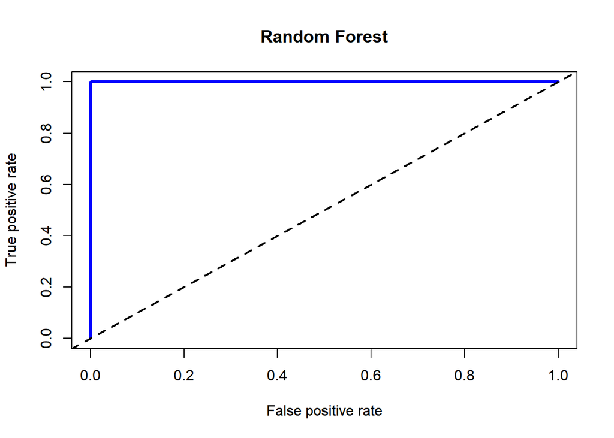

```r
rf_predictions_prob=predict(rf, mush_val, type="prob")
pred_rf <- prediction(rf_predictions_prob$e, mush_val$class, label.ordering = c("p","e"))
perf_rf<- performance(pred_rf, measure = "tpr", x.measure= "fpr")

#plot the ROC curve
plot(perf_rf, main = "Random Forest", col = "blue", lwd= 3)
abline(a = 0, b = 1, lwd= 2, lty= 2)
```

```r
#get the AUC
rf.perf.auc<-performance(pred_rf, measure = "auc")
rf_auc <- unlist(rf.perf.auc@y.values)
```

The Random Forest model has an AUC, Accuracy, Kappa, precision, and recall of 1.0. This model has either severely overfit the data, or is the perfect match for it (likely the former).

### Gradient Boosted Tree

```r
set.seed(1)
gbm <- train(mush_train[-1], mush_train$class, method = "gbm", trControl= trainControl("cv", number = 10))
gbm
```

```
## Stochastic Gradient Boosting
##
## 34352 samples
##    19 predictor
##     2 classes: 'e', 'p'
##
## No pre-processing
## Resampling: Cross-Validated (10 fold)
## Summary of sample sizes: 30916, 30917, 30917, 30917, 30917, 30917, ...
## Resampling results across tuning parameters:
##
##   interaction.depth  n.trees  Accuracy   Kappa
##   1                   50      0.7215302  0.4274724
##   1                  100      0.7645846  0.5205470
##   1                  150      0.7878436  0.5685586
##   2                   50      0.8085705  0.6102800
##   2                  100      0.8389908  0.6738433
##   2                  150      0.8748254  0.7472687
##   3                   50      0.8502273  0.6964497
##   3                  100      0.8949990  0.7876280
##   3                  150      0.9281556  0.8548267
##
## Tuning parameter 'shrinkage' was held constant at a value of 0.1
##
## Tuning parameter 'n.minobsinnode' was held constant at a value of 10
## Accuracy was used to select the optimal model using the largest value.
## The final values used for the model were n.trees = 150, interaction.depth =
##  3, shrinkage = 0.1 and n.minobsinnode = 10.
```

##### Predictions on Validation Data

```r
gmb_predictions <- predict(gbm, mush_val)
confusionMatrix(as.factor(gmb_predictions), as.factor(mush_val$class), positive="e")
```

```
## Confusion Matrix and Statistics
##
##           Reference
## Prediction    e    p
##          e 3580  344
##          p  291 4461
##
##                Accuracy : 0.9268
##                  95% CI : (0.9211, 0.9322)
##     No Information Rate : 0.5538
##     P-Value [Acc > NIR] : < 2e-16
##
##                   Kappa : 0.8521
##
##  Mcnemar's Test P-Value : 0.03906
##
##             Sensitivity : 0.9248
##             Specificity : 0.9284
##          Pos Pred Value : 0.9123
##          Neg Pred Value : 0.9388
##              Prevalence : 0.4462
##          Detection Rate : 0.4126
##    Detection Prevalence : 0.4523
##       Balanced Accuracy : 0.9266
##
##        'Positive' Class : e
##
```

```r
gbm_acc <- 0.9268
```

##### Area under ROC Curve

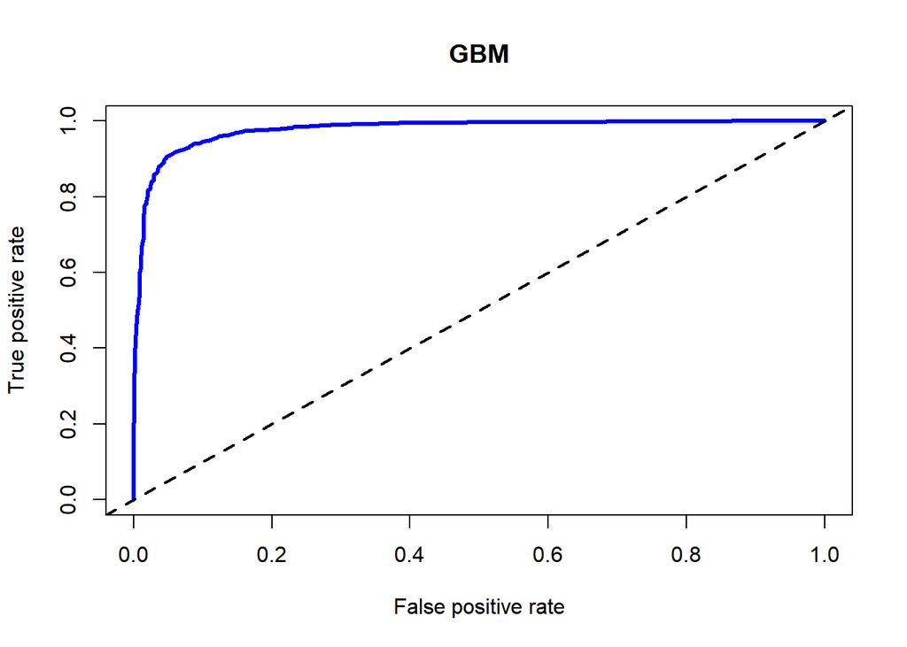

```r
gbm_predictions_prob=predict(gbm, mush_val, type="prob")
pred_gbm <- prediction(gbm_predictions_prob$e, mush_val$class, label.ordering = c("p","e"))
perf_gbm<- performance(pred_gbm, measure = "tpr", x.measure= "fpr")

#plot the ROC curve
plot(perf_gbm, main = "GBM", col = "blue", lwd= 3)
abline(a = 0, b = 1, lwd= 2, lty= 2)
```

```r
#get the AUC
gbm.perf.auc<-performance(pred_gbm, measure = "auc")
gbm_auc <- unlist(gbm.perf.auc@y.values)
```

### Data Preparation: Scaling & Encoding

SVMs and NNs require numeric data. Therefore it is time to scale and encode the data for use with these models. I will use z-score scaling for the numeric variables.

```r
library(mltools)
library(data.table)
```

#### Dummy Encode Categorical Features

I chose to dummy encode the categorical features because one-hot encoding would increase the dimensionality of the data frame, increasing the training time for the more complex machine learning models (such as tree ensembles and SVM).

```r
#copy data over to new dataframe to have an original df and a numeric df
mush_train_num <- mush_train
mush_val_num <- mush_val
mush_test_num <- mush_test
```

```r
#adjust the true/false features to 0/1 instead of 1/2
#has.ring, and does.bruise.or.bleed
mush_train_num$`has.ring` = ifelse(mush_train_num$`has.ring`=="t", 1, 0)
mush_val_num$`has.ring` = ifelse(mush_val_num$`has.ring`=="t", 1, 0)
mush_test_num$`has.ring` = ifelse(mush_test_num$`has.ring`=="t", 1, 0)
#does.bruise.or.bleed
mush_train_num$`does.bruise.or.bleed` = ifelse(mush_train_num$`does.bruise.or.bleed`=="t", 1, 0)
mush_val_num$`does.bruise.or.bleed` = ifelse(mush_val_num$`does.bruise.or.bleed`=="t", 1, 0)
mush_test_num$`does.bruise.or.bleed` = ifelse(mush_test_num$`does.bruise.or.bleed`=="t", 1, 0)
```

```r
#convert categorical classes to a number, dummy encode
categorical_cols <- c("cap.shape", "cap.color", "gill.color", "stem.color", "habitat", "season")
mush_train_num[categorical_cols] <- lapply(mush_train_num[categorical_cols], as.numeric)
mush_val_num[categorical_cols] <- lapply(mush_val_num[categorical_cols], as.numeric)
mush_test_num[categorical_cols] <- lapply(mush_test_num[categorical_cols], as.numeric)
```

#### Scaling Numeric Features

I will use z-score standardization. The features “does.bruise.or.bleed” and “has.ring” will not be scaled, as they are already input on a binary (0/1) scale.

```r
#SCALE NUMERIC VARIABLES
scale_cols = c("cap.diameter", "cap.shape", "cap.surface", "cap.color", "gill.attachment", "gill.spacing", "gill.color", "stem.height", "stem.width", "stem.root", "stem.surface", "stem.color", "veil.color", "ring.type", "spore.print.color", "habitat", "season")

#compute mean and sd of training data
col_means_train <- attr(scale(mush_train_num[,scale_cols]), "scaled:center")
col_stddevs_train <- attr(scale(mush_train_num[,scale_cols]), "scaled:scale")

#scale training data
mush_train_num[scale_cols] = scale(mush_train_num[scale_cols])

#scale validation data based on training data mean and stddev
mush_val_num[scale_cols]<- scale(mush_val_num[scale_cols], center = col_means_train,
                                   scale = col_stddevs_train)
#scale test data based on training data mean and stddev
mush_test_num[scale_cols]<- scale(mush_test_num[scale_cols], center = col_means_train,
                                    scale = col_stddevs_train)
```

## SVM models

### Linear Kernel

```r
set.seed(1)
svm_l<-train(mush_train_num[-1], as.factor(mush_train_num$class), method = "svmLinear",
             trControl= trainControl("cv", number = 10, classProbs = TRUE))
```

```r
svm_l
```

```
## Support Vector Machines with Linear Kernel
##
## 34352 samples
##    19 predictor
##     2 classes: 'e', 'p'
##
## No pre-processing
## Resampling: Cross-Validated (10 fold)
## Summary of sample sizes: 30916, 30917, 30917, 30917, 30917, 30917, ...
## Resampling results:
##
##   Accuracy  Kappa
##   0.664881  0.3094909
##
## Tuning parameter 'C' was held constant at a value of 1
```

##### Predictions on Validation Data

```r
svml_predictions <- predict(svm_l, mush_val_num[-1])
confusionMatrix(as.factor(svml_predictions), as.factor(mush_val_num$class), positive="e")
```

```
## Confusion Matrix and Statistics
##
##           Reference
## Prediction    e    p
##          e 2035 1097
##          p 1836 3708
##
##                Accuracy : 0.6619
##                  95% CI : (0.6519, 0.6719)
##     No Information Rate : 0.5538
##     P-Value [Acc > NIR] : < 2.2e-16
##
##                   Kappa : 0.303
##
##  Mcnemar's Test P-Value : < 2.2e-16
##
##             Sensitivity : 0.5257
##             Specificity : 0.7717
##          Pos Pred Value : 0.6497
##          Neg Pred Value : 0.6688
##              Prevalence : 0.4462
##          Detection Rate : 0.2346
##    Detection Prevalence : 0.3610
##       Balanced Accuracy : 0.6487
##
##        'Positive' Class : e
##
```

```r
svml_acc <- 0.6619
```

##### Area under ROC Curve

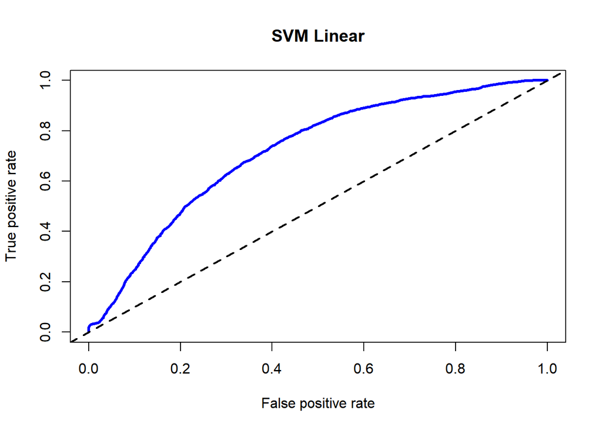

```r
svml_predictions_prob <- predict(svm_l, mush_val_num[-1], type="prob")
pred_svml <- prediction(svml_predictions_prob$e, mush_val_num$class, label.ordering = c("p","e"))
perf_svml<- performance(pred_svml, measure = "tpr", x.measure= "fpr")

#plot the ROC curve
plot(perf_svml, main = "SVM Linear", col = "blue", lwd= 3)
abline(a = 0, b = 1, lwd= 2, lty= 2)
```

```r
#get the AUC
svml.perf.auc<-performance(pred_svml, measure = "auc")
svml_auc <- unlist(svml.perf.auc@y.values)
```

### Radial Kernel

```r
set.seed(1)
svm_r<-train(mush_train_num[-1], as.factor(mush_train_num$class), method = "svmRadial",
             trControl= trainControl("cv", number = 10, classProbs = TRUE))
```

```
## line search fails -4.064058 0.1599535 1.159597e-05 3.512917e-07 -2.95767e-08 2.369989e-09 -3.42138e-13
```

```
## line search fails -4.07898 0.1615626 1.296619e-05 7.212059e-07 -3.341158e-08 2.306011e-09 -4.315579e-13
```

```
## line search fails -4.065534 0.1610765 1.14996e-05 3.907243e-07 -2.931628e-08 2.346185e-09 -3.362086e-13
```

```r
svm_r
```

```
## Support Vector Machines with Radial Basis Function Kernel
##
## 34352 samples
##    19 predictor
##     2 classes: 'e', 'p'
##
## No pre-processing
## Resampling: Cross-Validated (10 fold)
## Summary of sample sizes: 30916, 30917, 30917, 30917, 30917, 30917, ...
## Resampling results across tuning parameters:
##
##   C     Accuracy   Kappa
##   0.25  0.9473977  0.8934457
##   0.50  0.9642768  0.9276255
##   1.00  0.9812821  0.9620876
##
## Tuning parameter 'sigma' was held constant at a value of 0.03635167
## Accuracy was used to select the optimal model using the largest value.
## The final values used for the model were sigma = 0.03635167 and C = 1.
```

##### Predictions on Validation Data

```r
svmr_predictions <- predict(svm_r, mush_val_num[-1])
confusionMatrix(as.factor(svmr_predictions), as.factor(mush_val_num$class), positive="e")
```

```
## Confusion Matrix and Statistics
##
##           Reference
## Prediction    e    p
##          e 3792   61
##          p   79 4744
##
##                Accuracy : 0.9839
##                  95% CI : (0.981, 0.9864)
##     No Information Rate : 0.5538
##     P-Value [Acc > NIR] : <2e-16
##
##                   Kappa : 0.9673
##
##  Mcnemar's Test P-Value : 0.1508
##
##             Sensitivity : 0.9796
##             Specificity : 0.9873
##          Pos Pred Value : 0.9842
##          Neg Pred Value : 0.9836
##              Prevalence : 0.4462
##          Detection Rate : 0.4371
##    Detection Prevalence : 0.4441
##       Balanced Accuracy : 0.9834
##
##        'Positive' Class : e
##
```

```r
svmr_acc <- 0.9839
```

##### Area under ROC Curve

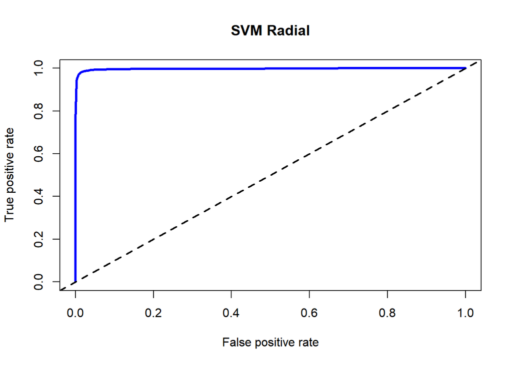

```r
svmr_predictions_prob <- predict(svm_r, mush_val_num[-1], type="prob")
pred_svmr <- prediction(svmr_predictions_prob$e, mush_val_num$class, label.ordering = c("p","e"))
perf_svmr<- performance(pred_svmr, measure = "tpr", x.measure= "fpr")

#plot the ROC curve
plot(perf_svmr, main = "SVM Radial", col = "blue", lwd= 3)
abline(a = 0, b = 1, lwd= 2, lty= 2)
```

```r
#get the AUC
svmr.perf.auc<-performance(pred_svmr, measure = "auc")
svmr_auc <- unlist(svmr.perf.auc@y.values)
```

## Artificial Neural Network

An artificial neural network requires numeric, scaled data. This data is already both of those, however the target variable is not numeric. Thus I will convert it to numeric.

```r
#convert target variable to numeric
mush_train_num_labels = ifelse(mush_train_num$class=="e", 1, 0)
mush_val_num_labels = ifelse(mush_val_num$class=="e", 1, 0)

mush_train_num$class = NULL
mush_val_num$class = NULL
```

```r
library(keras)
library(tfruns)
```

### Tuning the Neural Network

```r
set.seed(1)
#mushrooms.R script includes the flags for hyper-parameter tuning on the validation dataset
runs <- tuning_run("mushrooms.R",
                    flags = list(
                    nodes = c(25, 50, 100),
                    learning_rate = c(0.01, 0.05, 0.001),
                    batch_size=c(16,32,64),
                    activation=c("relu","sigmoid","tanh"),
                    dropout=c(0.2,0.5,0.7)
                  ),
                  sample = 0.03 )
```

[output not shown]

[output cut: 359 more lines]

[output not shown]

```r
runs= runs[order(runs$metric_val_loss),]
runs
```

|  | run_dir | metric_loss | metric_accuracy | metric_val_loss | metric_val_accuracy | flag_nodes | flag_batch_size | flag_activation | flag_learning_rate | flag_epochs | flag_dropout | epochs | epochs_completed | metrics | model | loss_function | optimizer | learning_rate | script | start | end | completed | output | source_code | context | type |
| --- | --- | --- | --- | --- | --- | --- | --- | --- | --- | --- | --- | --- | --- | --- | --- | --- | --- | --- | --- | --- | --- | --- | --- | --- | --- | --- |
| 5 | runs/2024-05-01T21-59-54Z | 0.1368 | 0.9466 | 0.0187 | 0.9964 | 100 | 64 | tanh | 0.001 | 50 | 0.5 | 50 | 50 | runs/2024-05-01T21-59-54Z/tfruns.d/metrics.json | Model: "sequential"\n________________________________________________________________________________\n Layer (type) Output Shape Param # \n============================================================… | binary_crossentropy |  | 0.001 | mushrooms.R | 2024-05-01 21:59:54.97024 | 2024-05-01 22:01:08.79311 | TRUE | \n> FLAGS callbacks = list(callback_early_stopping(monitor = "val_loss", \n+ patience = 5, restore_best_weights = TRUE))\n\n> model = keras_model_sequential()\n\n> model %>% layer_dense(units = FLAGS$… | runs/2024-05-01T21-59-54Z/tfruns.d/source.tar.gz | local | training |
| 6 | runs/2024-05-01T21-58-51Z | 0.1081 | 0.9607 | 0.0285 | 0.9973 | 100 | 64 | sigmoid | 0.010 | 50 | 0.5 | 50 | 42 | runs/2024-05-01T21-58-51Z/tfruns.d/metrics.json | Model: "sequential"\n________________________________________________________________________________\n Layer (type) Output Shape Param # \n============================================================… | binary_crossentropy |  | 0.010 | mushrooms.R | 2024-05-01 21:58:51.44888 | 2024-05-01 21:59:54.69393 | TRUE | \n> FLAGS callbacks = list(callback_early_stopping(monitor = "val_loss", \n+ patience = 5, restore_best_weights = TRUE))\n\n> model = keras_model_sequential()\n\n> model %>% layer_dense(units = FLAGS$… | runs/2024-05-01T21-58-51Z/tfruns.d/source.tar.gz | local | training |
| 8 | runs/2024-05-01T21-56-42Z | 0.1891 | 0.9286 | 0.0664 | 0.9778 | 50 | 32 | tanh | 0.050 | 50 | 0.2 | 50 | 15 | runs/2024-05-01T21-56-42Z/tfruns.d/metrics.json | Model: "sequential"\n________________________________________________________________________________\n Layer (type) Output Shape Param # \n============================================================… | binary_crossentropy |  | 0.050 | mushrooms.R | 2024-05-01 21:56:47.39422 | 2024-05-01 21:58:01.08208 | TRUE | \n> FLAGS callbacks = list(callback_early_stopping(monitor = "val_loss", \n+ patience = 5, restore_best_weights = TRUE))\n\n> model = keras_model_sequential()\n\n> model %>% layer_dense(units = FLAGS$… | runs/2024-05-01T21-56-42Z/tfruns.d/source.tar.gz | local | training |
| 3 | runs/2024-05-01T22-02-14Z | 0.2316 | 0.8998 | 0.1225 | 0.9629 | 25 | 32 | sigmoid | 0.001 | 50 | 0.2 | 50 | 50 | runs/2024-05-01T22-02-14Z/tfruns.d/metrics.json | Model: "sequential"\n________________________________________________________________________________\n Layer (type) Output Shape Param # \n============================================================… | binary_crossentropy |  | 0.001 | mushrooms.R | 2024-05-01 22:02:14.95634 | 2024-05-01 22:04:16.97212 | TRUE | \n> FLAGS callbacks = list(callback_early_stopping(monitor = "val_loss", \n+ patience = 5, restore_best_weights = TRUE))\n\n> model = keras_model_sequential()\n\n> model %>% layer_dense(units = FLAGS$… | runs/2024-05-01T22-02-14Z/tfruns.d/source.tar.gz | local | training |
| 1 | runs/2024-05-01T22-04-42Z | 0.2556 | 0.8926 | 0.1436 | 0.9501 | 100 | 64 | sigmoid | 0.010 | 50 | 0.7 | 50 | 50 | runs/2024-05-01T22-04-42Z/tfruns.d/metrics.json | Model: "sequential"\n________________________________________________________________________________\n Layer (type) Output Shape Param # \n============================================================… | binary_crossentropy |  | 0.010 | mushrooms.R | 2024-05-01 22:04:43.16073 | 2024-05-01 22:05:57.47572 | TRUE | \n> FLAGS callbacks = list(callback_early_stopping(monitor = "val_loss", \n+ patience = 5, restore_best_weights = TRUE))\n\n> model = keras_model_sequential()\n\n> model %>% layer_dense(units = FLAGS$… | runs/2024-05-01T22-04-42Z/tfruns.d/source.tar.gz | local | training |
| 2 | runs/2024-05-01T22-04-16Z | 0.4731 | 0.7212 | 0.3863 | 0.7397 | 50 | 32 | relu | 0.050 | 50 | 0.2 | 50 | 10 | runs/2024-05-01T22-04-16Z/tfruns.d/metrics.json | Model: "sequential"\n________________________________________________________________________________\n Layer (type) Output Shape Param # \n============================================================… | binary_crossentropy |  | 0.050 | mushrooms.R | 2024-05-01 22:04:17.26568 | 2024-05-01 22:04:42.87689 | TRUE | \n> FLAGS callbacks = list(callback_early_stopping(monitor = "val_loss", \n+ patience = 5, restore_best_weights = TRUE))\n\n> model = keras_model_sequential()\n\n> model %>% layer_dense(units = FLAGS$… | runs/2024-05-01T22-04-16Z/tfruns.d/source.tar.gz | local | training |
| 4 | runs/2024-05-01T22-01-08Z | 0.4905 | 0.7047 | 0.4402 | 0.7185 | 50 | 64 | sigmoid | 0.001 | 50 | 0.7 | 50 | 50 | runs/2024-05-01T22-01-08Z/tfruns.d/metrics.json | Model: "sequential"\n________________________________________________________________________________\n Layer (type) Output Shape Param # \n============================================================… | binary_crossentropy |  | 0.001 | mushrooms.R | 2024-05-01 22:01:09.07297 | 2024-05-01 22:02:14.67189 | TRUE | \n> FLAGS callbacks = list(callback_early_stopping(monitor = "val_loss", \n+ patience = 5, restore_best_weights = TRUE))\n\n> model = keras_model_sequential()\n\n> model %>% layer_dense(units = FLAGS$… | runs/2024-05-01T22-01-08Z/tfruns.d/source.tar.gz | local | training |
| 7 | runs/2024-05-01T21-58-01Z | 0.7553 | 0.5525 | 0.6951 | 0.4462 | 50 | 16 | relu | 0.050 | 50 | 0.7 | 50 | 11 | runs/2024-05-01T21-58-01Z/tfruns.d/metrics.json | Model: "sequential"\n________________________________________________________________________________\n Layer (type) Output Shape Param # \n============================================================… | binary_crossentropy |  | 0.050 | mushrooms.R | 2024-05-01 21:58:01.35983 | 2024-05-01 21:58:51.17747 | TRUE | \n> FLAGS callbacks = list(callback_early_stopping(monitor = "val_loss", \n+ patience = 5, restore_best_weights = TRUE))\n\n> model = keras_model_sequential()\n\n> model %>% layer_dense(units = FLAGS$… | runs/2024-05-01T21-58-01Z/tfruns.d/source.tar.gz | local | training |

```r
#print the run with the lowest validation loss
view_run(runs$run_dir[5])
```

```
## starting httpd help server ... done
```

```r
#create the model
model = keras_model_sequential() %>%
  layer_dense(units = 100,                          #first hidden layer
              activation = 'sigmoid',
              input_shape = dim(mush_train_num)[2] ) %>%
  layer_dropout(0.7) %>%                            #drop out layer
  layer_dense(units = 100,                          #second hidden layer
              activation = 'sigmoid') %>%
  layer_dropout(0.7) %>%                            #drop out layer
  layer_dense(units = 1,                            #output layer
              activation = 'sigmoid')               #activation must be sigmoid due to binary output
```

```r
#compile the model
model %>% compile(
  optimizer = optimizer_adam(learning_rate=0.01),
  loss = 'binary_crossentropy',                     #loss must be binary cross entropy due to binary output
  metrics="acc")
```

```r
#fit the model
set.seed(1)
history <- model %>% fit(as.matrix(mush_train_num),
              mush_train_num_labels,
              epochs=50,
              batch_size= 64)
```

```
## 537/537 - 2s - loss: 0.6257 - acc: 0.6341 - 2s/epoch - 4ms/step
## 537/537 - 1s - loss: 0.5299 - acc: 0.6819 - 1s/epoch - 2ms/step
## 537/537 - 1s - loss: 0.4842 - acc: 0.7078 - 1s/epoch - 2ms/step
## 537/537 - 1s - loss: 0.4620 - acc: 0.7240 - 1s/epoch - 2ms/step
## 537/537 - 1s - loss: 0.4413 - acc: 0.7418 - 1s/epoch - 2ms/step
## 537/537 - 1s - loss: 0.4344 - acc: 0.7485 - 1s/epoch - 2ms/step
## 537/537 - 1s - loss: 0.4203 - acc: 0.7603 - 1s/epoch - 2ms/step
## 537/537 - 1s - loss: 0.4135 - acc: 0.7696 - 1s/epoch - 2ms/step
## 537/537 - 1s - loss: 0.4050 - acc: 0.7740 - 1s/epoch - 2ms/step
## 537/537 - 1s - loss: 0.3978 - acc: 0.7858 - 1s/epoch - 2ms/step
## 537/537 - 1s - loss: 0.3845 - acc: 0.7950 - 1s/epoch - 2ms/step
## 537/537 - 1s - loss: 0.3816 - acc: 0.8003 - 1s/epoch - 2ms/step
## 537/537 - 1s - loss: 0.3773 - acc: 0.8085 - 1s/epoch - 2ms/step
## 537/537 - 1s - loss: 0.3655 - acc: 0.8160 - 1s/epoch - 2ms/step
## 537/537 - 1s - loss: 0.3586 - acc: 0.8245 - 1s/epoch - 2ms/step
## 537/537 - 1s - loss: 0.3552 - acc: 0.8252 - 1s/epoch - 2ms/step
## 537/537 - 1s - loss: 0.3509 - acc: 0.8306 - 1s/epoch - 2ms/step
## 537/537 - 1s - loss: 0.3430 - acc: 0.8347 - 1s/epoch - 2ms/step
## 537/537 - 1s - loss: 0.3384 - acc: 0.8397 - 1s/epoch - 2ms/step
## 537/537 - 1s - loss: 0.3328 - acc: 0.8452 - 1s/epoch - 2ms/step
## 537/537 - 1s - loss: 0.3287 - acc: 0.8491 - 1s/epoch - 2ms/step
## 537/537 - 1s - loss: 0.3220 - acc: 0.8513 - 1s/epoch - 2ms/step
## 537/537 - 1s - loss: 0.3201 - acc: 0.8534 - 1s/epoch - 2ms/step
## 537/537 - 1s - loss: 0.3175 - acc: 0.8568 - 1s/epoch - 2ms/step
## 537/537 - 1s - loss: 0.3151 - acc: 0.8605 - 1s/epoch - 2ms/step
## 537/537 - 1s - loss: 0.3130 - acc: 0.8595 - 1s/epoch - 2ms/step
## 537/537 - 1s - loss: 0.3095 - acc: 0.8606 - 1s/epoch - 2ms/step
## 537/537 - 1s - loss: 0.3054 - acc: 0.8636 - 1s/epoch - 2ms/step
## 537/537 - 1s - loss: 0.3028 - acc: 0.8653 - 1s/epoch - 2ms/step
## 537/537 - 1s - loss: 0.3031 - acc: 0.8668 - 1s/epoch - 2ms/step
## 537/537 - 1s - loss: 0.2971 - acc: 0.8698 - 1s/epoch - 2ms/step
## 537/537 - 1s - loss: 0.2940 - acc: 0.8715 - 1s/epoch - 2ms/step
## 537/537 - 1s - loss: 0.3001 - acc: 0.8680 - 1s/epoch - 2ms/step
## 537/537 - 1s - loss: 0.2940 - acc: 0.8709 - 1s/epoch - 2ms/step
## 537/537 - 1s - loss: 0.2839 - acc: 0.8771 - 1s/epoch - 2ms/step
## 537/537 - 1s - loss: 0.2848 - acc: 0.8788 - 1s/epoch - 2ms/step
## 537/537 - 1s - loss: 0.2825 - acc: 0.8799 - 1s/epoch - 2ms/step
## 537/537 - 1s - loss: 0.2805 - acc: 0.8793 - 1s/epoch - 2ms/step
## 537/537 - 1s - loss: 0.2810 - acc: 0.8803 - 1s/epoch - 2ms/step
## 537/537 - 1s - loss: 0.2785 - acc: 0.8816 - 1s/epoch - 2ms/step
## 537/537 - 1s - loss: 0.2804 - acc: 0.8847 - 1s/epoch - 2ms/step
## 537/537 - 1s - loss: 0.2787 - acc: 0.8813 - 1s/epoch - 2ms/step
## 537/537 - 1s - loss: 0.2722 - acc: 0.8855 - 1s/epoch - 2ms/step
## 537/537 - 1s - loss: 0.2735 - acc: 0.8839 - 1s/epoch - 2ms/step
## 537/537 - 1s - loss: 0.2724 - acc: 0.8850 - 1s/epoch - 2ms/step
## 537/537 - 1s - loss: 0.2660 - acc: 0.8884 - 1s/epoch - 2ms/step
## 537/537 - 1s - loss: 0.2681 - acc: 0.8859 - 1s/epoch - 2ms/step
## 537/537 - 1s - loss: 0.2667 - acc: 0.8881 - 1s/epoch - 2ms/step
## 537/537 - 1s - loss: 0.2669 - acc: 0.8891 - 1s/epoch - 2ms/step
## 537/537 - 1s - loss: 0.2673 - acc: 0.8871 - 1s/epoch - 2ms/step
```

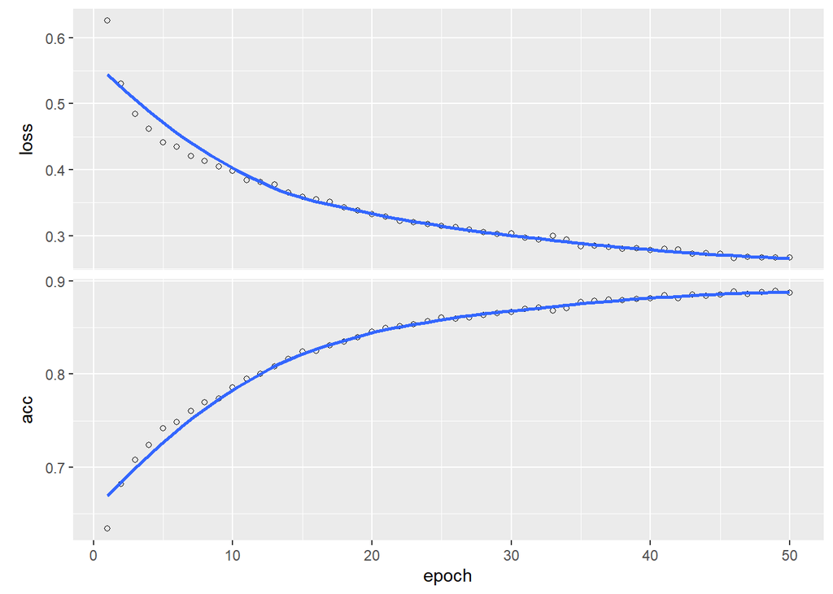

```r
plot(history)
```